# Joao_clean_version

```r
library(tidyverse)
library(DescTools)
library(estimatr)
library(fastDummies)
# read in the csv and choose the columns we will use
data <- read.csv('endline.csv', header = TRUE)
data <- data[, c("grade", "female", "age", "language", "region", "school_type",
                 "encrypted_school_code", "treatment", "read_comp_score", "orf")]

#school_type is collinear with treatment. Have to drop it. Grouping all controls regardless of type under "control" makes this variable useless.
data <- data %>% select(-school_type)

# change the treatment variable to a binary integer
data$treatment <- ifelse(data$treatment == "Control", 0, 1)

# change school code to be 1,...,num_schools, remove original column
data$school_id <- as.numeric(factor(data$encrypted_school_code, levels = unique(data$encrypted_school_code)))
data <- data %>% select(-encrypted_school_code)

# convert character columns to factor
data[sapply(data, is.character)] <- lapply(data[sapply(data, is.character)], as.factor)

# remove rows with NAs
data <- na.omit(data)

# Age has a skewed distro with a massive outlier (someone aged 100). Will drop outlier as it seems like an error
data <- data[data$age <= 60, ]

# set up covariates (X), response (Y), and treatment (Z)
X <- data[, c("grade", "female", "age", "language")]
Z <- data$treatment
Y <- data$read_comp_score # can also use orf (oral reading fluency)
```

# Baseline school-level analysis

```r
school_level_data <- data %>%
  group_by(school_id) %>%
  summarise(
    orf = mean(orf, na.rm = TRUE),
    r_comp_scr = mean(read_comp_score, na.rm = TRUE),
    z = mean(treatment, na.rm = TRUE)
  )

y1 <- school_level_data$orf
y2 <- school_level_data$r_comp_scr
z <- school_level_data$z

model <- lm(y1 ~ z, data = school_level_data)
model_summary_orf <- summary(model)

model <- lm(y2 ~ z, data = school_level_data)
model_summary_r_comp <- summary(model)

print("--- ORF Results ---")
```

```
## [1] "--- ORF Results ---"
```

```r
model_summary_orf$coefficients["z", ]
```

```
##   Estimate Std. Error    t value   Pr(>|t|)
## 3.39648169 1.62469607 2.09053357 0.03763119
```

```r
print("--- Reading Comp Results ---")
```

```
## [1] "--- Reading Comp Results ---"
```

```r
model_summary_r_comp$coefficients["z", ]
```

```
##   Estimate Std. Error    t value   Pr(>|t|)
## 0.19612568 0.10359887 1.89312566 0.05955434
```

- Doing a simple analysis at the school level shows that there is only a statistically significant treatment effect on oral reading fluency, not reading comprehension. However, this didn’t deploy any variance reduction techniques, which could render statistically significant results for both.

# school-level covariates

```r
# collapse student covariates to school level for the propensity model
school_summary <- X %>%
  mutate(school_id = data$school_id) %>%
  group_by(school_id) %>%
  mutate(num_2grade = sum(grade == 2)) %>%
  mutate(num_3grade = sum(grade == 3)) %>%
  mutate(num_female = sum(female == "Female")) %>%
  mutate(num_male = sum(female == "Male")) %>%
  mutate(avg_age = mean(age)) %>%
  mutate(sd_age = sd(age)) %>%
  mutate(common_language = Mode(language)) %>%
  select(-grade, -female, -age, -language) %>%
  distinct()
head(school_summary)
```

```
## # A tibble: 6 × 8
## # Groups:   school_id [6]
##   school_id num_2grade num_3grade num_female num_male avg_age sd_age
##       <dbl>      <int>      <int>      <int>    <int>   <dbl>  <dbl>
## 1         1         20         20         19       20    9.52   1.26
## 2         2         21         19         20       20   10.3    1.67
## 3         3         20         20         20       20   10.5    1.92
## 4         4         20         20         20       20    9.98   1.67
## 5         5         19         20         20       19   10.4    1.66
## 6         6         20         20         20       20   10.7    1.18
## # ℹ 1 more variable: common_language <fct>
```

# school-level analysis with lin’s estimator (variance reduction)

```r
##OHE common language
school_covars <- dummy_cols(school_summary,
                   select_columns = "common_language",
                   remove_first_dummy = TRUE)

#removing ids and common language
school_covars <- school_covars %>%
  select(-common_language, -school_id)

#commented code below removes covariates that I suspect are modeling noise
#school_covars <- school_covars %>%
#  select(-common_language, -school_id,-num_male,-num_female,-num_2grade,-num_3grade)

# Center the covariates
school_covars_centered <- scale(school_covars, center = TRUE, scale = FALSE)

X_centered <- as.data.frame(school_covars_centered)

analysis_df <- data.frame(
  orf = school_level_data$orf,           # Y1
  read_score = school_level_data$r_comp_scr, # Y2
  z = school_level_data$z,               # Treatment
  X_centered                             # All centered covariates
)

#Create regression formula dynamically
covariate_names <- colnames(X_centered)
rhs_formula <- paste("z * (", paste(covariate_names, collapse = " + "), ")")

#Model for ORF (Y1)
formula_orf <- as.formula(paste("orf ~", rhs_formula))
lin_model_orf <- lm_robust(formula_orf, data = analysis_df)

#Model for Reading Score (Y2)
formula_read <- as.formula(paste("read_score ~", rhs_formula))
lin_model_read <- lm_robust(formula_read, data = analysis_df)

# results
print("--- Lin's Estimator Results (ORF) ---")
```

```
## [1] "--- Lin's Estimator Results (ORF) ---"
```

```r
summary(lin_model_orf)$coefficients["z", ]
```

```
##     Estimate   Std. Error      t value     Pr(>|t|)     CI Lower     CI Upper
##   2.62391599   1.42462950   1.84182343   0.06685941  -0.18389427   5.43172624
##           DF
## 218.00000000
```

```r
print("--- Lin's Estimator Results (Reading Score) ---")
```

```
## [1] "--- Lin's Estimator Results (Reading Score) ---"
```

```r
summary(lin_model_read)$coefficients["z", ]
```

```
##     Estimate   Std. Error      t value     Pr(>|t|)     CI Lower     CI Upper
##   0.15471234   0.09355501   1.65370456   0.09962677  -0.02967575   0.33910044
##           DF
## 218.00000000
```

# Student-level analysis with Lin’s estimator

```r
##OHE language
X_enc <- dummy_cols(X,
                   select_columns = "language",
                   remove_first_dummy = TRUE)
X_enc$female <- ifelse(X_enc$female =="Female",1,0)
#keeping only covars
X_enc <- X_enc %>%
  select(-language)

# Center the covariates
X_enc_cen <- scale(X_enc, center = TRUE, scale = FALSE)

X_centered <- as.data.frame(X_enc_cen)

analysis_df <- data.frame(
  orf = data$orf,                    # Y1
  read_score = data$read_comp_score, # Y2
  z = Z,                             # Treatment
  school_id = data$school_id,        # school id
  X_centered                         # All centered covariates
)

#Create regression formula dynamically
covariate_names <- colnames(X_centered)
rhs_formula <- paste("z * (", paste(covariate_names, collapse = " + "), ")")

#Model for ORF (Y1)
formula_orf <- as.formula(paste("orf ~", rhs_formula))
lin_model_orf <- lm_robust(formula_orf, data = analysis_df,clusters =school_id )

#Model for Reading Score (Y2)
formula_read <- as.formula(paste("read_score ~", rhs_formula))
lin_model_read <- lm_robust(formula_read, data = analysis_df,clusters =school_id)

# results
print("--- Lin's Estimator Results (ORF) student-level ---")
```

```
## [1] "--- Lin's Estimator Results (ORF) student-level ---"
```

```r
summary(lin_model_orf)$coefficients["z", ]
```

```
##     Estimate   Std. Error      t value     Pr(>|t|)     CI Lower     CI Upper
##   3.26337937   1.42191812   2.29505435   0.02263957   0.46159521   6.06516352
##           DF
## 227.94332633
```

```r
print("--- Lin's Estimator Results (Reading Score) student-level ---")
```

```
## [1] "--- Lin's Estimator Results (Reading Score) student-level ---"
```

```r
summary(lin_model_read)$coefficients["z", ]
```

```
##     Estimate   Std. Error      t value     Pr(>|t|)     CI Lower     CI Upper
## 1.886584e-01 9.195331e-02 2.051676e+00 4.134409e-02 7.471242e-03 3.698456e-01
##           DF
## 2.279433e+02
```

*An analysis utilizing Lin’s estimator at the student level showed that the intervention is statistically significant for both ORF and reading comprehension. The contrast with previous results is likely due to the fact that the aggregated covariates at the school level weren’t very meaningful and allowed for noise in the model. Also in this set up with have a higher DF given lower amount of covariates.

#AIPW utilizing causal forrests

*Causal forests handles cross fitting and hyper parameter tuning so we only need to train the model. It also builds the propensity score and outcome models simultaneously

```r
library(grf)
Y1<- data$orf
Y2<- data$read_comp_score
school <- data$school_id
cf1 <- causal_forest(
  X = X_centered,
  Y = Y1,
  W = Z,
  clusters = school,
  tune.parameters = "all"
)
cf2 <- causal_forest(
  X = X_centered,
  Y = Y2,
  W = Z,
  clusters = school,
  tune.parameters = "all"
)
```

```r
print("----Results for ORF----")
```

```
## [1] "----Results for ORF----"
```

```r
ate_result_orf <- average_treatment_effect(cf1, target.sample = "all")
print(ate_result_orf)
```

```
## estimate  std.err
## 3.256079 1.391544
```

```r
#getting variables that have the greatest interaction with treatment
varimp <- variable_importance(cf1)
ranked_vars <-order(varimp, decreasing = TRUE)
colnames(X_centered)[ranked_vars]
```

```
## [1] "grade"              "female"             "age"
## [4] "language_Amharic"   "language_Sidamigna" "language_Somaligna"
## [7] "language_Tigrigna"
```

```r
#checking predictors of treatment effect
best_linear_projection(cf1, X_centered)
```

```
##
## Best linear projection of the conditional average treatment effect.
## Confidence intervals are cluster- and heteroskedasticity-robust (HC3):
##
##                    Estimate Std. Error t value Pr(>|t|)
## (Intercept)         3.25608    1.41054  2.3084  0.02100 *
## grade               2.39566    1.33322  1.7969  0.07238 .
## female              0.24333    0.94788  0.2567  0.79741
## age                -0.25100    0.34024 -0.7377  0.46070
## language_Amharic   -1.29276    3.89622 -0.3318  0.74005
## language_Sidamigna -5.36273    3.13285 -1.7118  0.08697 .
## language_Somaligna -3.29798    6.23606 -0.5289  0.59692
## language_Tigrigna  -2.14360    3.17705 -0.6747  0.49987
## ---
## Signif. codes:  0 '***' 0.001 '**' 0.01 '*' 0.05 '.' 0.1 ' ' 1
```

```r
print("----Results for Reading Comp----")
```

```
## [1] "----Results for Reading Comp----"
```

```r
ate_result_read_comp <- average_treatment_effect(cf2, target.sample = "all")
print(ate_result_read_comp)
```

```
##   estimate    std.err
## 0.18841661 0.09027766
```

```r
#getting variables that have the greatest interaction with treatment
varimp <- variable_importance(cf2)
ranked_vars <-order(varimp, decreasing = TRUE)
colnames(X_centered)[ranked_vars]
```

```
## [1] "grade"              "female"             "age"
## [4] "language_Amharic"   "language_Sidamigna" "language_Somaligna"
## [7] "language_Tigrigna"
```

```r
#checking predictors of treatment effect
best_linear_projection(cf2, X_centered)
```

```
##
## Best linear projection of the conditional average treatment effect.
## Confidence intervals are cluster- and heteroskedasticity-robust (HC3):
##
##                     Estimate Std. Error t value Pr(>|t|)
## (Intercept)         0.188417   0.091674  2.0553  0.03988 *
## grade               0.094981   0.084238  1.1275  0.25955
## female             -0.010865   0.062451 -0.1740  0.86188
## age                -0.027768   0.023408 -1.1862  0.23556
## language_Amharic   -0.110605   0.229883 -0.4811  0.63043
## language_Sidamigna -0.362486   0.193532 -1.8730  0.06110 .
## language_Somaligna -0.241618   0.492858 -0.4902  0.62398
## language_Tigrigna  -0.285247   0.193411 -1.4748  0.14029
## ---
## Signif. codes:  0 '***' 0.001 '**' 0.01 '*' 0.05 '.' 0.1 ' ' 1
```

*Results are similar to those found utilizing lin’s estimator at the student level.* HTE to note: Seems like the treatment is less effective across the board for the Sidamigna language. It also seems like the treatment has a greater effect on ORF for 3rd grade students.

# Clusters with Doubly-Robust Estimand

- We conduct a cluster random experiment with school as the cluster.
- Each school is assigned to be treatment or control, so all units within the same cluster have the same treatment assignment.
- Denote each school as a variable $S$ where $S \in {1,...,K}$

```r
schools <- unique(data$school_id)
K <- length(schools)
paste0("Number of schools: ", K)
```

```
## [1] "Number of schools: 240"
```

- We have 240 schools in the experiment, so $K = 240$.
- Just as a sanity check, we will now make sure that each school contains only treatment units or only control units.
- We will then check the number of treatment schoola and the number of control schools.

```r
schools_treatment <- data %>%
  group_by(school_id) %>%
  mutate(num_students = n()) %>%
  mutate(num_treatment = sum(treatment)) %>%
  mutate(num_control = n() - sum(treatment)) %>%
  select(school_id, num_students, num_treatment, num_control) %>%
  distinct() %>%
  mutate(treatment = as.numeric(num_treatment > 0))
head(schools_treatment)
```

```
## # A tibble: 6 × 5
## # Groups:   school_id [6]
##   school_id num_students num_treatment num_control treatment
##       <dbl>        <int>         <dbl>       <dbl>     <dbl>
## 1         1           40             0          40         0
## 2         2           40            40           0         1
## 3         3           40            40           0         1
## 4         4           40            40           0         1
## 5         5           39            39           0         1
## 6         6           40            40           0         1
```

```r
num_control_schools <- sum(schools_treatment$num_control > 0)
paste0("Number of control schools: ", num_control_schools)
```

```
## [1] "Number of control schools: 120"
```

```r
num_treatment_schools <- sum(schools_treatment$num_treatment > 0)
paste0("Number of treatment schools: ", num_treatment_schools)
```

```
## [1] "Number of treatment schools: 120"
```

- We have 120 treatment schools and 120 control schools.
- Denote $n_{[k]} = \#\{i:X_{i}=k\}$.
- Let $T_{k} \in \{0,1\}$, $k=1,...,K$, be the treatment indicator for each cluster.
- We create vectors to store the $n_{k}$’s, the $k$’s, and the $T_{k}$’s.

```r
nk_vec <- schools_treatment$num_students
k_vec <- schools_treatment$school_id
T_vec <- schools_treatment$treatment
```

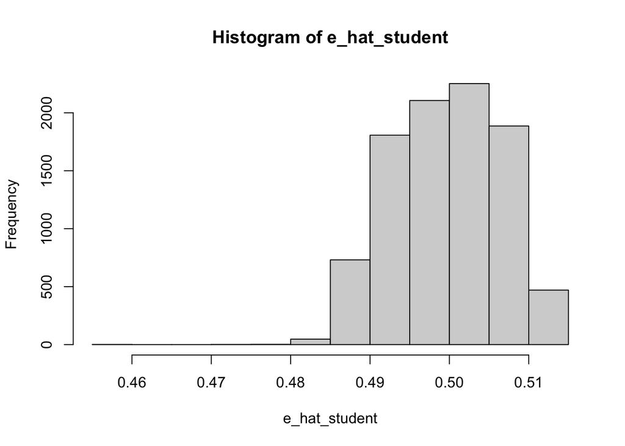

```r
# estimate propensity score using logistic regression
ps_model_student <- glm(Z ~ . , data = X_enc, family = binomial)
e_hat_student <- ps_model_student$fitted.values
hist(e_hat_student)
```

* As expected, propensity scores are centered around 0.5 given the randomized setup.

```r
# estimate outcome model using linear regression
out_mod <- lm(Y ~ Z + ., data = X)

data_Z1 <- X
data_Z1$Z <- 1
data_Z0 <- X
data_Z0$Z <- 0

mu1_hat <- predict(out_mod, newdata = data_Z1)
mu0_hat <- predict(out_mod, newdata = data_Z0)
```

- Now that we have propensity score and outcome model prediction fro each student/school, we can compute a doubly-robust AIPW estimand for each student. Our final estimand will be the mean of these values.

```r
# AIPW score per student
aipw <- (Z * (Y - mu1_hat) / e_hat_student) - ((1 - Z) * (Y - mu0_hat) / (1 - e_hat_student)) + (mu1_hat - mu0_hat)
tau_hat <- mean(aipw)
paste0("tau_hat = ", tau_hat)
```

```
## [1] "tau_hat = 0.187707792002109"
```

- We can now compute a variance estimate of our estimand.

```r
# cluster-robust variance: aggregate student contributions per school
# Use cluster-level sums U_s = sum_{i in s} aipw_i
U_s <- tapply(aipw, data$school_id, sum)   # length S
S <- length(U_s)
U_bar <- mean(U_s)
N <-length(aipw)

# variance estimator: Var(tau_hat) = S/N^2 * Var_emp(U_s) where Var_emp uses (S-1) denom
var_hat <- (S / (N^2)) * (sum( (U_s - U_bar)^2) / (S - 1))
se_hat  <- sqrt(var_hat)
paste0("SE_hat = ", se_hat)
```

```
## [1] "SE_hat = 0.0904227876276484"
```

- Using this standard error approximation, we can compute a confidence interval.

```r
# 95% CI
ci_lower <- tau_hat - qt(0.975, df = S - 1) * se_hat
ci_upper <- tau_hat + qt(0.975, df = S - 1) * se_hat

paste0("95% confidence interval: [", ci_lower, ", ", ci_upper, "]")
```

```
## [1] "95% confidence interval: [0.00958037946154383, 0.365835204542674]"
```